# Group Lasso Regression

Apa Marco(848154), Conte Enrico (852679), Filip Sara (852864)

# Descrizione del Problema

Il Dataset “Splice” contiene 400 siti di splice di donatori umani con una sequenza di 7 basi. La variabile binaria “y” indica se la i-esima combinazione corrisponde o meno ad un sito di splice (codificato con 1 in caso affermativo e 0 viceversa). Il nostro obbiettivo è quell di costruire un modello che sia capace di rilevare se una data combinazione di basi in una delle 7 posizioni corrisponde ad un sito di splice.

Come primo passo importiamo le librerie necessarie all’analisi e guardiamo la struttura dei dati.

# I Dati

```r
library(grplasso)
library(dplyr)
library(caTools)
library(car)
library(ROCR)
library(ggplot2)
library(DT)

data(splice)
datatable(splice)
```

|  | y | Pos.1 | Pos.2 | Pos.3 | Pos.4 | Pos.5 | Pos.6 | Pos.7 |
| --- | --- | --- | --- | --- | --- | --- | --- | --- |
| 7287 | 1 | g | a | g | g | a | g | a |
| 3772 | 1 | g | a | g | a | g | g | a |
| 5933 | 1 | a | a | a | g | a | g | t |
| 5918 | 1 | c | a | g | g | g | g | c |
| 5034 | 1 | c | a | g | g | g | g | g |
| 3349 | 1 | a | a | g | t | a | g | t |
| 1695 | 1 | c | t | g | g | a | g | t |
| 5338 | 1 | c | a | g | g | a | g | g |
| 7239 | 1 | g | g | g | a | a | g | c |
| 5914 | 1 | g | a | c | a | c | g | t |

[output cut: 390 more lines]

Per impostare correttamente il problema di regressione, dato che abbiamo a che fare con dati categorici, andiamo a definire la lista dei contrasti. Ogni contrasto corrisponde ad una delle sette posizioni sul filamento di DNA e ognuno dei 4 livelli di ogni contrasto consiste nella singola base azotata.

# Definizione Contrasti

```r
# Definiamo una lista contenente i contrasti dei fattori creati
contr <- rep(list("contr.treatment", base=NULL), ncol(splice)-1, )
names(contr) <- names(splice)[-1]
```

Andiamo ora a splittare i dati in Training set e Test Set. Operiamo un campionamento 80%-20% stratificato sulla variabile di risposta “y”.

## Splitting dei Dati

```r
# Splitting dati in Training e Test Set (80-20)

set.seed(1)
sample=sample.split(splice$y,SplitRatio = 0.80)
train_set=subset(splice,sample==TRUE)
test_set=subset(splice,sample==FALSE)
```

## Fitting del Modello

Impostiamo il modello di Regressione Logistica con tecnica “Group Lasso” al fine di operare, contestualmente al fitting, anche uno “shrinkage” dei coefficienti.

```r
logmodel <- grplasso(y ~ ., data = train_set, model = LogReg(), lambda = seq(15, 0, by= -1),
                       contrasts = contr, center = TRUE, standardize = TRUE)
```

```
## Lambda: 15  nr.var: 16
## Lambda: 14  nr.var: 19
## Lambda: 13  nr.var: 19
## Lambda: 12  nr.var: 19
## Lambda: 11  nr.var: 19
## Lambda: 10  nr.var: 19
## Lambda: 9  nr.var: 19
## Lambda: 8  nr.var: 19
## Lambda: 7  nr.var: 22
## Lambda: 6  nr.var: 22
## Lambda: 5  nr.var: 22
## Lambda: 4  nr.var: 22
## Lambda: 3  nr.var: 22
## Lambda: 2  nr.var: 22
## Lambda: 1  nr.var: 22
## Lambda: 0  nr.var: 22
```

Stiamo programmando il fitting di 16 modelli successivi. La differenza tra questi modelli è la scelta del parametro di penalizzazione lambda. In particolare, scegliamo di testare valori di lambda da 0 a 15 in ordine decrescente con stepsize = -1

## Coefficient path

Visualizziamo ora il “sentiero” dei coefficienti, ovvero vediamo come cambiano i valori dei coefficienti dei vari gruppi in funzione del valore decrescente di lambda. Possiamo vedere come, all’aumentare di lambda, tutti i coefficienti si avvicinino allo 0.

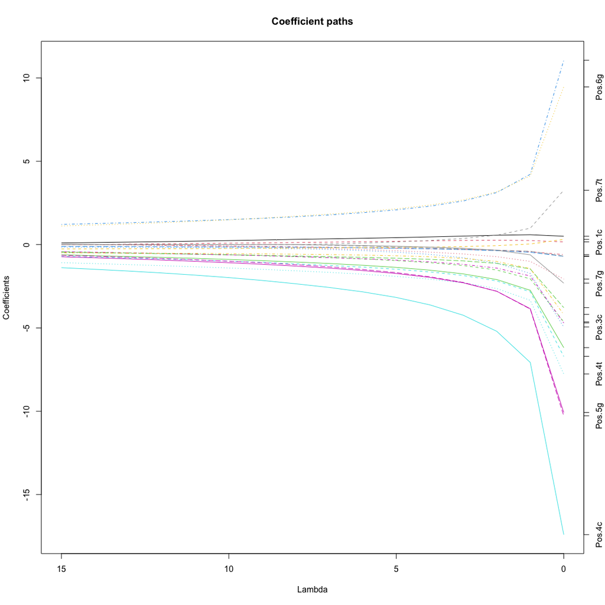

```r
#Coefficient Path
plot(logmodel)
```

## Predizioni

Le predizioni di un modello di Regressione Logistica sono codificate tra i valori [0,1]. Qui, plottiamo il valore delle predizioni fatte da 5 modelli con diversi valori di lambda sullo stesso Test Set. Il nostro obiettivo, in questo caso, è quello di vedere il grado di “incertezza” di ogni modello. Ovvero, quante delle predizioni del modello sono più vicine al valore medio tra 0 e 1 piuttosto che ad uno degli estremi.

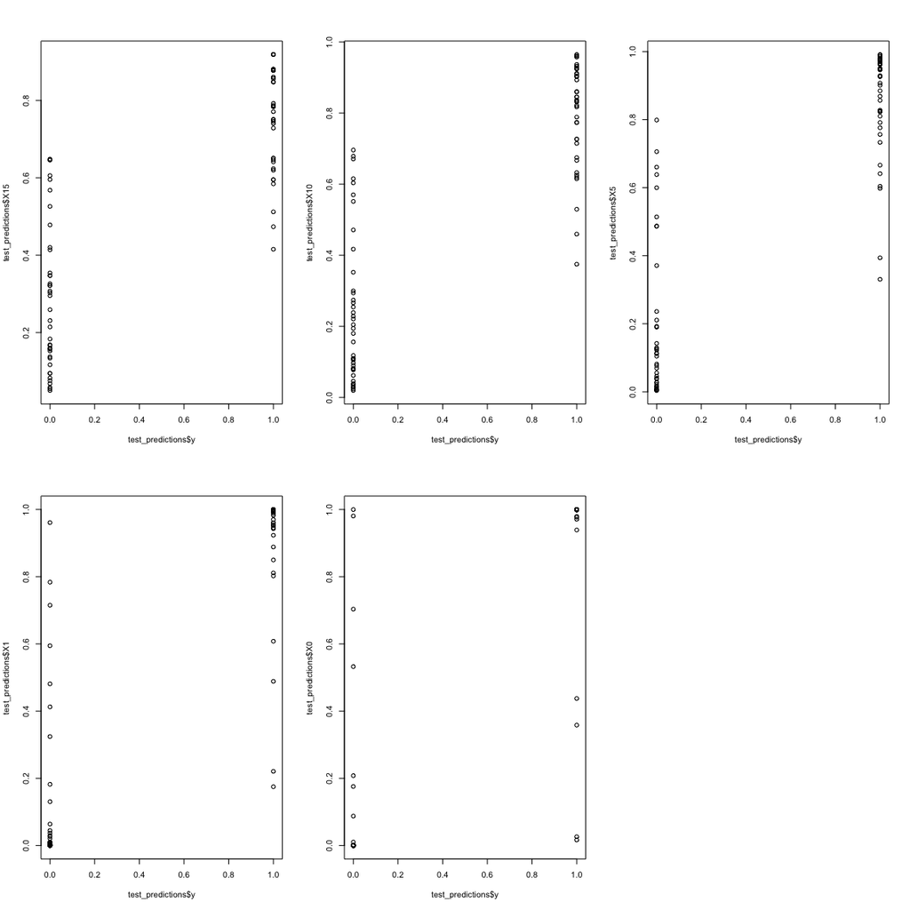

```r
# Procedura di visualizzazione per valori multipli di lambda.
test_predictions <- predict(logmodel, test_set[-test_set$y], type = 'response')
test_predictions <- data.frame(test_predictions)
test_predictions$y <- test_set$y

par(mfrow=c(2,3))
plot(test_predictions$y, test_predictions$X15)
plot(test_predictions$y, test_predictions$X10)
plot(test_predictions$y, test_predictions$X5)
plot(test_predictions$y, test_predictions$X1)
plot(test_predictions$y, test_predictions$X0)
```

## Scoring del Modello Migliore

[figure not shown]

```r
#  Curva ROC Penalizzata
par(mfrow=c(1,1))
predictTrain <- predict(logmodel, type = 'response')
ROCRpred_penalizzata = prediction(predictTrain[, 16], train_set$y)
ROCRperf_penalizzata= performance(ROCRpred_penalizzata,'tpr','fpr')
plot(ROCRperf_penalizzata, colorize=TRUE, print.cutoffs.at=seq(0,1,by=0.1),
     text.adj=c(-0.2,2), main = "Regressione Group Lasso con lambda = 15")
```

```r
# Area sotto la curva
auc_penalizzata = as.numeric(performance(ROCRpred_penalizzata, 'auc')@y.values)
# Accuracy con valore-soglia di 0.75
predictTest = predict(logmodel, newdata = test_set ,type = "response")
conf_matrix <- table(test_set$y, predictTest[, 16] >= 0.8)               # Accuracy del modello con lambda = 15
conf_matrix
```

```
##
##     FALSE TRUE
##   0    38    2
##   1     4   36
```

```r
accuracy_penalizzata <- (38+36)/(38+36+4+2)
print(paste('Livello di Accuracy:', accuracy_penalizzata,' ; Area Sotto la Curva:', auc_penalizzata))
```

```
## [1] "Livello di Accuracy: 0.925  ; Area Sotto la Curva: 0.9962109375"
```

[figure not shown]

```r
#  Curva ROC Non Penalizzata
par(mfrow=c(1,1))
predictTrain <- predict(logmodel, type = 'response')
ROCRpred = prediction(predictTrain[, 1], train_set$y)
ROCRperf= performance(ROCRpred,'tpr','fpr')
plot(ROCRperf, colorize=TRUE, print.cutoffs.at=seq(0,1,by=0.1),
     text.adj=c(-0.2,2), main = "Regressione Lineare NON Penalizzata")
```

```r
# Area sotto la curva
auc = as.numeric(performance(ROCRpred, 'auc')@y.values)
# Accuracy con valore-soglia di 0.75
predictTest = predict(logmodel, newdata = test_set ,type = "response")
conf_matrix <- table(test_set$y, predictTest[, 1] >= 0.75)               # Accuracy del modello con lambda = 15
conf_matrix
```

```
##
##     FALSE TRUE
##   0    40    0
##   1    16   24
```

```r
accuracy <- (40+24)/(40+24+16)
print(paste('Livello di Accuracy:', accuracy,' ; Area Sotto la Curva:', auc))
```

```
## [1] "Livello di Accuracy: 0.8  ; Area Sotto la Curva: 0.984609375"
```